# Time Series Analysis of COVID-19 in Georgia

04/18/2021

## 1. Introduction

About one year ago, the coronavirus disease of 2019 (COVID-19) had been declared a global pandemic, as it infected and spread around people quite easily. This virus caused many deaths, and forced people to work virtually, and properly protect themselves by wearing face masks when out in public.

After over a year, several companies and researchers actively worked on developing a vaccine to help people develop immunity against this contagious virus [1], and help people get their lives back to normal. Vaccines have been offered since the start of the 2021, and have been made available to certain age groups over periods of time. They have primarily been manufactured by Moderna, Pfizer, and Johnson and Johnson. Demand for vaccines has been overwhelming as people are trying to get back to normal.

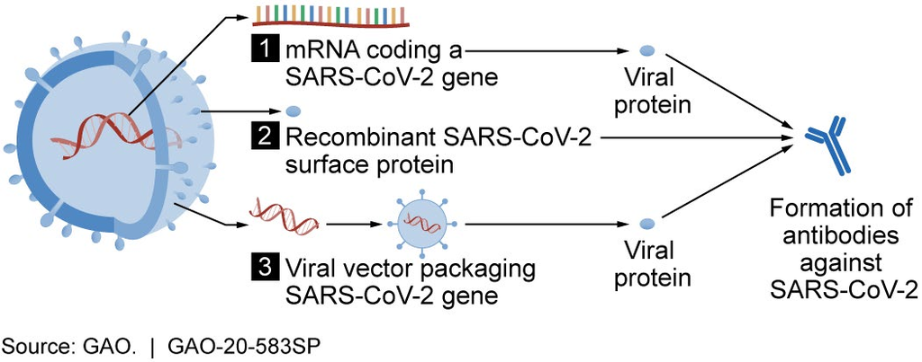

For our project, we decided to investigate COVID-19 data since there are many time series based datasets on the pandemic. As vaccines have been distributed in recent times, we decided to examine vaccinations in the US by state, from a dataset provided at the links [2,3].

Our primary focus was people vaccinated and people fully vaccinated, and we considered fitting a POMP model and an ARMA model to look for trends and evaluate results.The data for this project comes from two principal sources: The New York Times, and Our World in Data. The former was utilized for Covid case data, and the latter for vaccination counts.

The NYT dataset provides information at both the state and county level. To control for state-level confounding variables while maintaining a reasonably-sized dataset, we opted to limit data to a single state. We selected Georgia based on the relative smoothness of its time series data. Our principal variable of interest is the total number of cumulative covid cases by state, including both lab-confirmed and probable. Due to recommendations of the Council of State and Territorial Epidemiologists, the CDC adopted inclusion of both lab-confirmed and probable cases on April 5th, 2020. Therefore, we will use this definition for our case count.

The cleaned and merged dataset for Georgia contains 413 observations, but only 97 of these have non-zero vaccination data, due to the relatively recent approval of vaccines.

## 2. Exploratory Data Analysis

### 2.1.Data description

The data for this project comes from two principal sources: The New York Times, and Our World in Data. The former was utilized for Covid case data, and the latter for vaccination counts.

The NYT dataset provides information at both the state and county level. To control for state-level confounding variables while maintaining a reasonably-sized dataset, we opted to limit data to a single state. We selected Georgia based on the relative smoothness of its time series data. Our principal variable of interest is the total number of cumulative covid cases by state, including both lab-confirmed and probable. Due to recommendations of the Council of State and Territorial Epidemiologists, the CDC adopted inclusion of both lab-confirmed and probable cases on April 5th, 2020. Therefore, we will use this definition for our case count.

The cleaned and merged dataset for Georgia contains 413 observations, but only 97 of these have non-zero vaccination data, due to the relatively recent approval of vaccines.

### 2.2.Exploratory Analysis

First, we examine some univariate time series plots for vaccinations and covid cases.

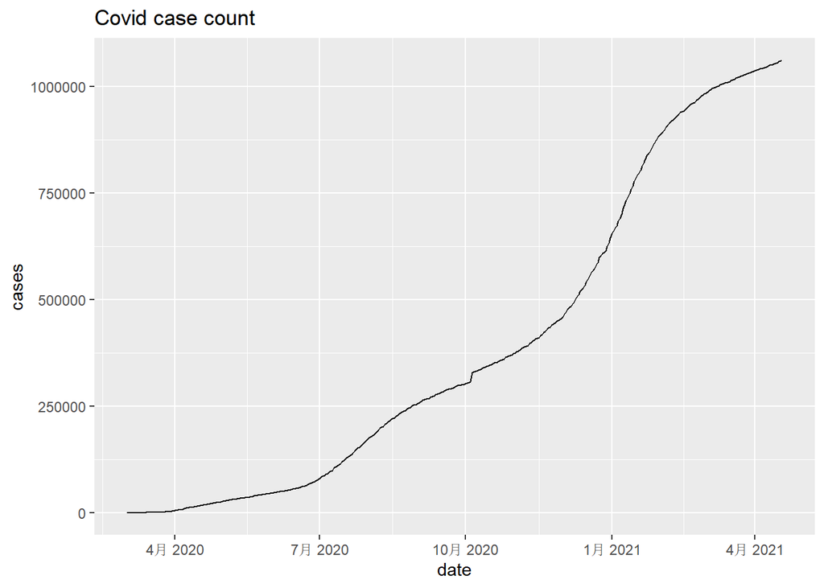

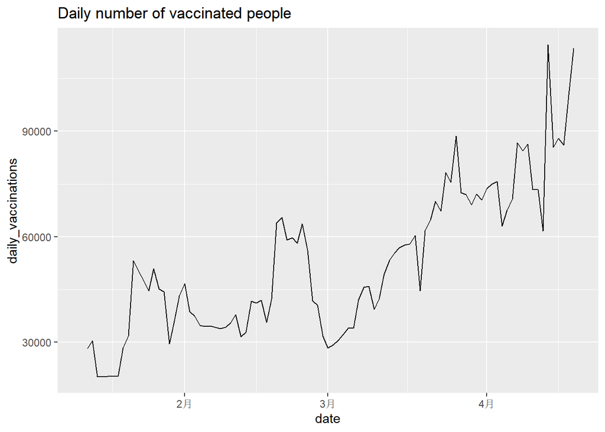

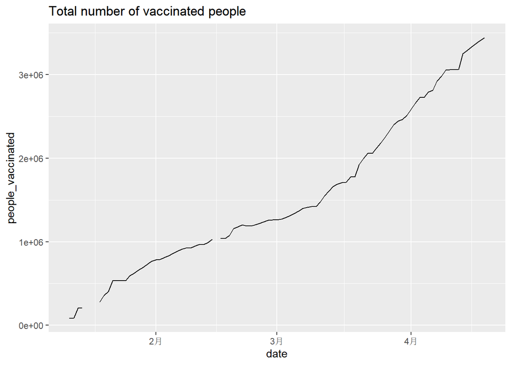

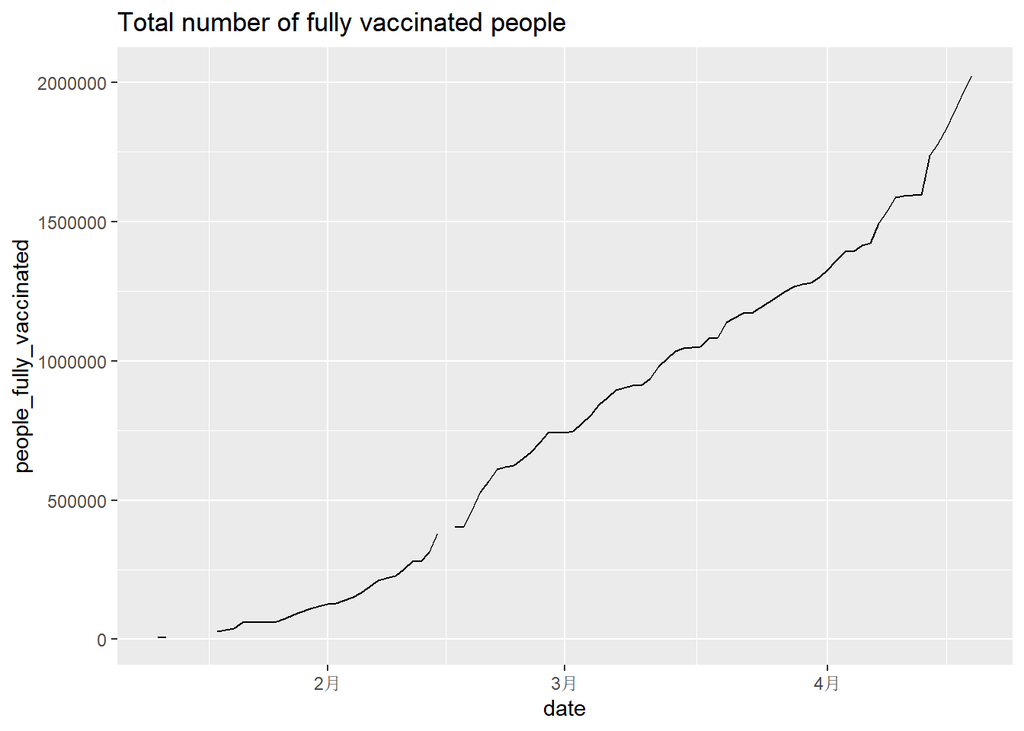

Then, we try to model the susceptable population.

To get a clearer idea of the trajectory of the COVID-19 pandemic in Georgia, we can estimate the remaining susceptible population and plot this in tandem with case and vaccination counts.

In estimating the susceptible population, the following simplifications have been made: 1. We use the 2019 census estimate of 10.62 million for the population of Georgia 2. We assume that the vaccine is “perfect”, i.e. a fully vaccinated person is completely removed from the susceptible population 3. We assume that anyone who has recovered from the Coronavirus has maintained their antibodies and will not be reinfected

The calculation is given by
$$X_{susceptible} = X_{population} - X_{fully~vaccinated} - X_{previous~covid} - X_{deaths}$$

Note that we account for only deaths from COVID-19, since the very high number of Covid deaths in the U.S. may disproportionately affect the expected yearly population dynamics.

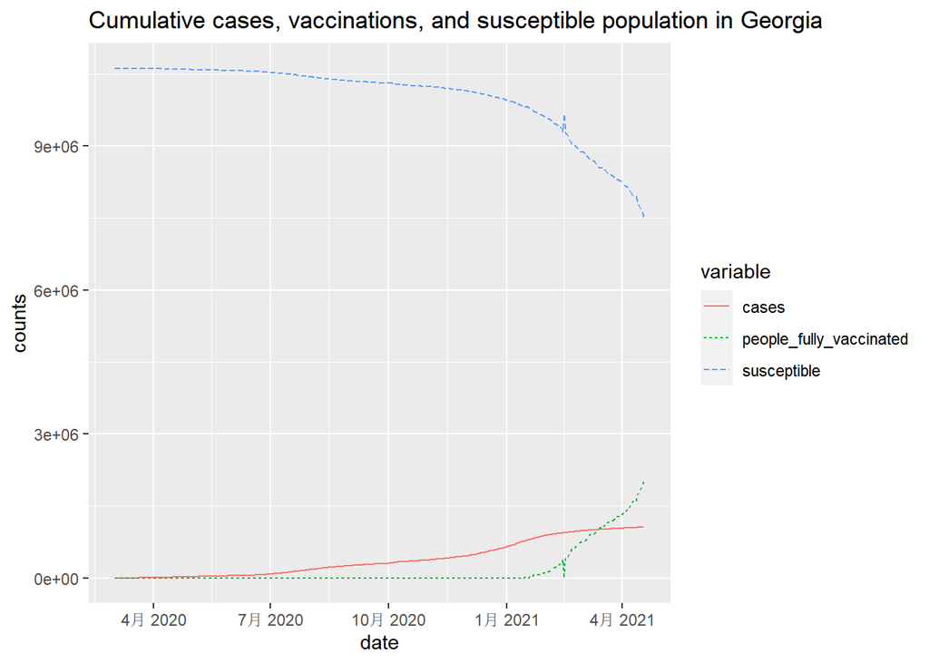

While the number of fully vaccinated people has surpassed the number of cumulative COVID-19 cases, the large proportion of the population that remains susceptible might have implications for the future of the pandemic in Georgia. More specifically, it is reasonable to assume that Georgia has not reached the vaccination threshold for herd immunity, and the large proportion of susceptible individuals may indicate that the spread of COVID-19 in Georgia could continue for some time. However, since the vaccination curve is increasing quite rapidly, the susceptible population is dwindling at a similar rate, providing evidence that Georgia may reach herd immunity fairly soon. The plot does not provide strong enough evidence for either scenario, but such a visualization remains helpful for understanding the basic viral dynamics at play.

## 3. ARMA Model

We begin by analyzing the rate of vaccinations in Georgia. From the plots, we see that the trend of people who are fully vaccinated increases at a roughly quadratic rate with little noise, while the number of daily vaccinations increases linearly or quadratically with much more noise in the data. Due to the lack of noise in the fully vaccinated counts, we can simply fit a quadratic model depending on the number of days since the first fully vaccinated individual to explain the rate of vaccination.

|  | Estimate | Std. Error | t value | Pr(>\|t\|) |
| --- | --- | --- | --- | --- |
| (Intercept) | -102608.69895 | 23889.400815 | -4.295156 | 4.36e-05 |
| day | 11582.98624 | 1055.819356 | 10.970614 | 0.00e+00 |
| I(day^2) | 92.18955 | 9.960918 | 9.255126 | 0.00e+00 |

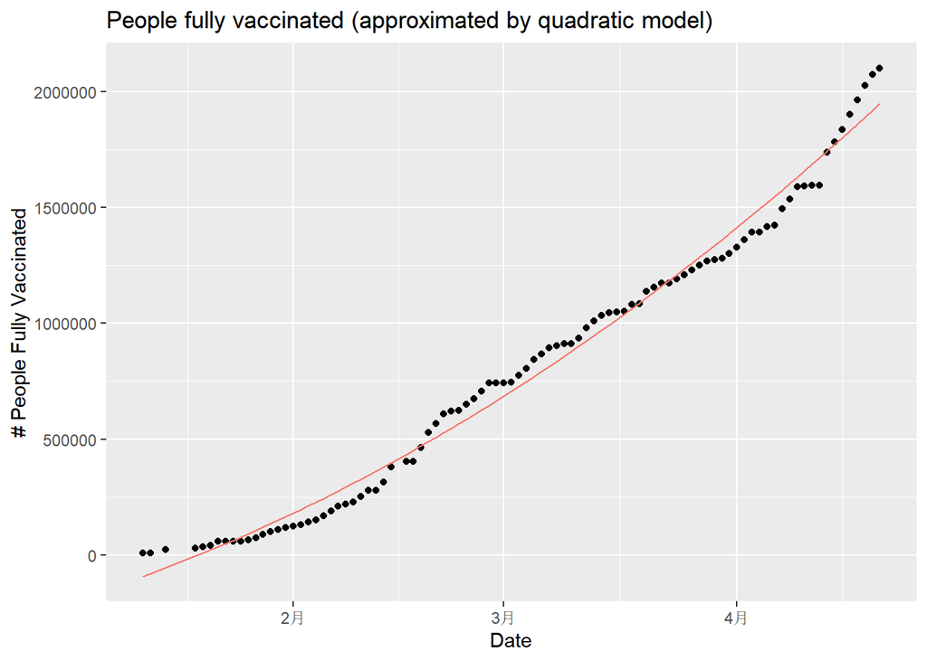

|  | MA0 | MA1 | MA2 | MA3 | MA4 | MA5 |
| --- | --- | --- | --- | --- | --- | --- |
| AR0 | 2194.087 | 2167.134 | 2153.002 | 2151.953 | 2147.516 | 2149.314 |
| AR1 | 2142.594 | 2122.099 | 2123.191 | 2125.191 | 2143.759 | 2123.406 |
| AR2 | 2137.062 | 2123.253 | 2124.150 | 2122.569 | 2123.058 | 2119.957 |
| AR3 | 2137.608 | 2124.909 | 2123.695 | 2115.339 | 2117.277 | 2117.335 |
| AR4 | 2129.731 | 2121.725 | 2122.133 | 2117.303 | 2119.224 | 2119.791 |
| AR5 | 2129.880 | 2123.587 | 2123.243 | 2117.873 | 2119.860 | 2112.625 |

The most complicated model we fit (AR5, MA5) has the lowest AIC, but since this is both a highly complex model and at the upper bound of the coefficients we tested, we disregard this result, searching instead for well-performing models with smaller coefficients. We see that both models with coefficients (1) AR4, MA4 and (0) AR1 MA1 are viable candidates. We perform a likelihood ratio test to choose between them, where the test statistic:

$$X = 2(l_1 - l_0)$$

follows a $\chi^2_2$ distribution, and $l_1,\,l_0$ are the log-likelihoods of model 1 and 0 respectively.

```
## [1] 1.535314e-06
```

The p-value is less than 0.05, so we conclude that model (1) is a significant improvement over model (0). Now let’s consider the plot

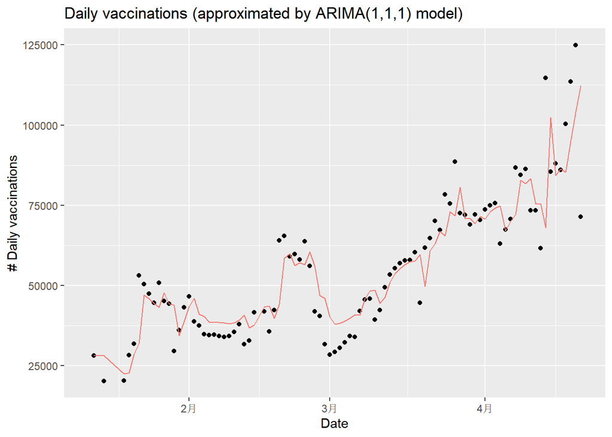

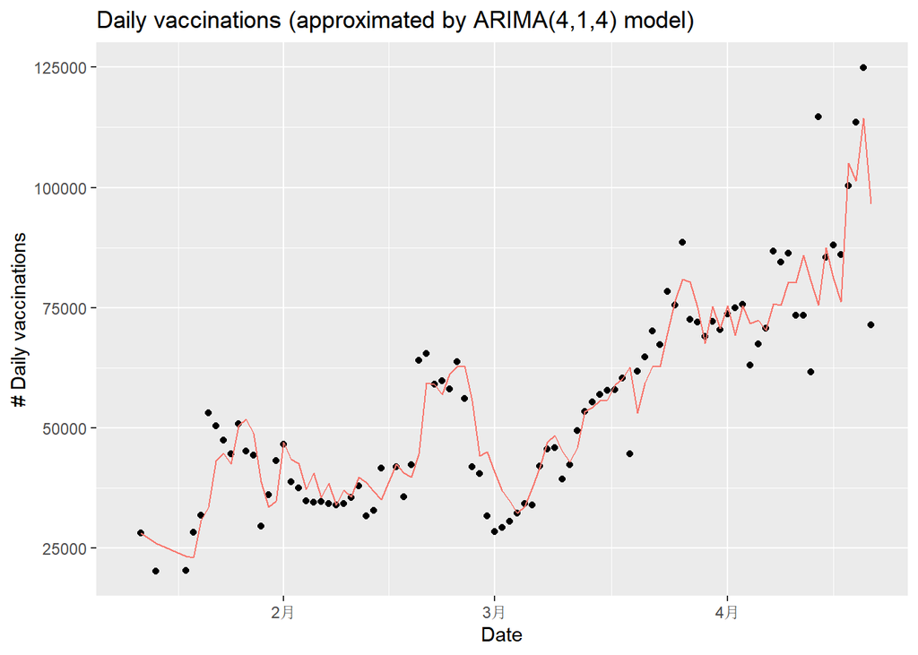

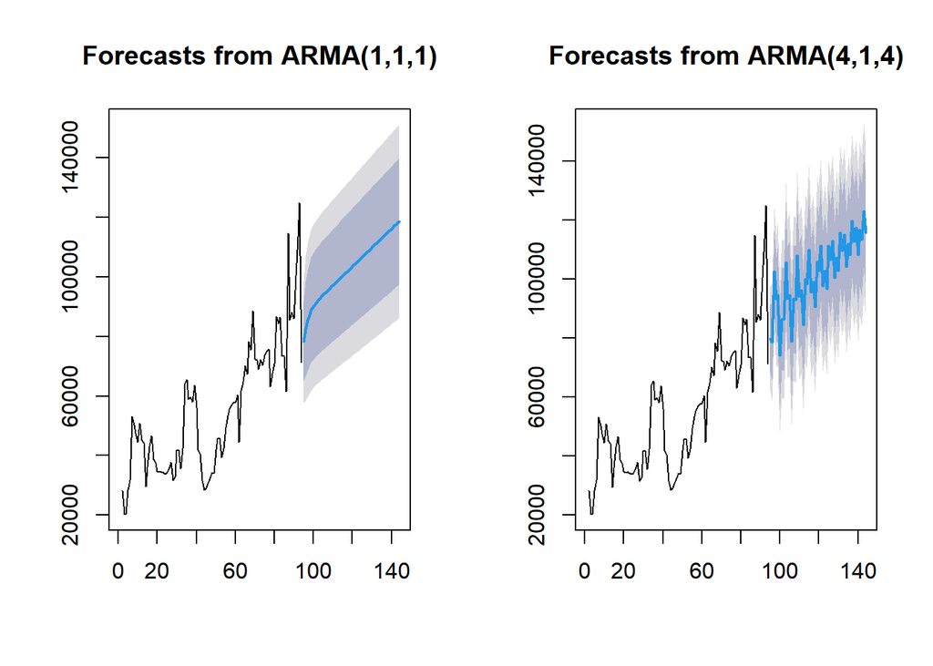

What we can see from the plots tells us that the more complicated ARMA(4,1,4) model is more sensitive to the slight fluctuations in the daily vaccinations data, hence improving its model fit over ARMA(1,1,1). However, the forecasted daily vaccinations from the ARMA(4,1,4) model have memory of the noisy data which aren’t useful for projections, whereas the forecasted daily vaccinations from the ARMA(1,1,1) model simply provide an upward trend with confidence bounds that anticipate differening rates of vaccine administration. Therefore, the additional complexity of the ARMA(4,1,4) model doesn’t provide additional value to our analysis, since we are interested in using a general model for vaccinations. The coefficients of the AMRA(1,1,1) model are:

|  | x |
| --- | --- |
| ar1 | 0.2928080 |
| ma1 | -0.6682007 |

Next, we examine the effect that introducing vaccinations as a covariate has on the covid cases. We do this by first fitting an ARMA model for covid cases prior to the first fully vaccinated person in Georgia, then we fit a linear regression with ARMA errors and daily vaccinations as a covariate. We begin by searching for a degree of differencing until the covid cases are roughly zero-centered.

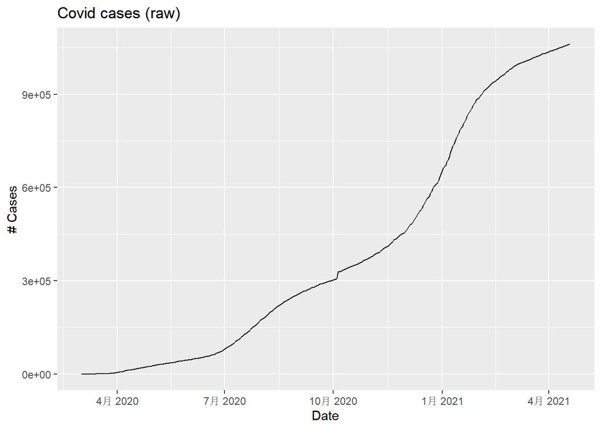

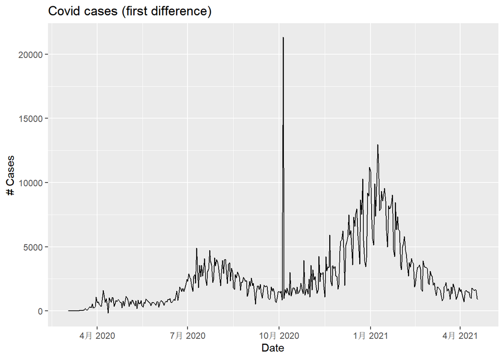

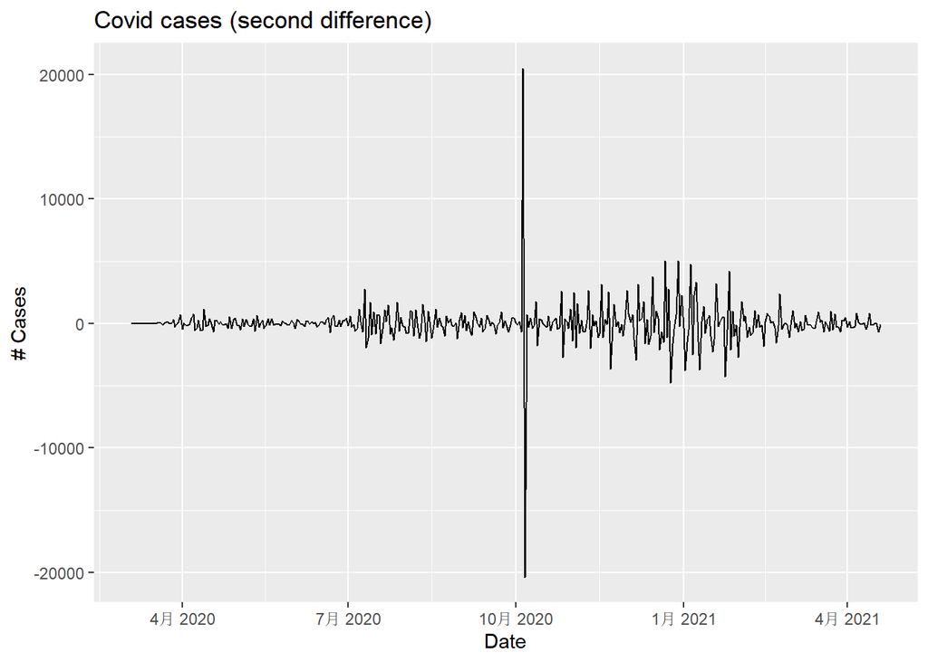

We settle for a 2nd degree differencing. Then we proceed to searching for ARMA coefficients using the pre-vaccination data.

|  | MA0 | MA1 | MA2 | MA3 | MA4 | MA5 |
| --- | --- | --- | --- | --- | --- | --- |
| AR0 | 5659.478 | 5515.257 | 5515.653 | 5517.554 | 5514.627 | 5513.959 |
| AR1 | 5590.751 | 5515.639 | 5517.635 | 5519.258 | 5514.747 | 5516.434 |
| AR2 | 5574.899 | 5517.623 | 5519.517 | 5520.141 | 5497.885 | 5517.712 |
| AR3 | 5564.130 | 5515.252 | 5506.347 | 5498.169 | 5501.476 | 5501.791 |
| AR4 | 5550.751 | 5510.046 | 5506.207 | 5502.925 | 5502.098 | 5499.594 |
| AR5 | 5535.606 | 5505.416 | 5503.357 | 5500.775 | 5503.397 | 5501.789 |

We move forward with the ARIMA(2,2,4) model:

|  | x |
| --- | --- |
| ar1 | 1.2423698 |
| ar2 | -0.9479046 |
| ma1 | -2.0771213 |
| ma2 | 2.0059354 |
| ma3 | -0.9003426 |
| ma4 | 0.0939152 |

Next, we fit a linear regression model with the number of people fully vaccinated as a covariate and ARIMA(2,2,4) errors.

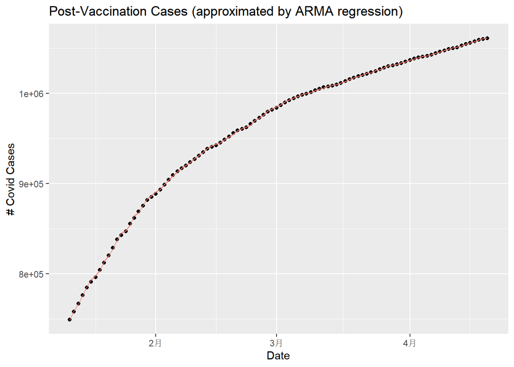

|  | x |
| --- | --- |
| ar1 | 0.1051912 |
| ar2 | 0.0138013 |
| ma1 | -0.6485558 |
| ma2 | -0.4154905 |
| ma3 | -0.1494905 |
| ma4 | 0.7262754 |
| xreg | -0.0003041 |

As we can see from the plot, the model fits the data very well, but the estimated coefficient for the number of people fully vaccinated is very small. This is not the behavior we expected, as we are looking for evidence that vaccinations are decreasing covid cases. We run into the limiations of ARMA methods of modeling, so we move forward to other approaches to find trends of covid cases and vaccinations.

## 4. POMP Model

### 4.1. Model Description

Lecture 12 shows that SEIR model has an additional exposed compartment on the basis of SIR model [4]. The exposed compartment means a latent period before the true infection (shown in Figure below).

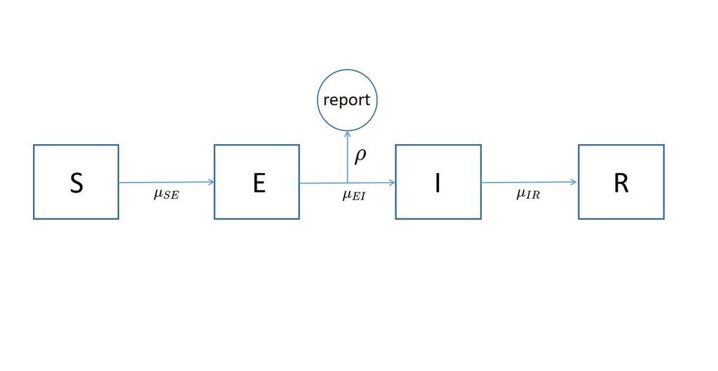

COVID-19 has an obvious 1-14 days latent period [5], which makes the SEIR model more applicable in our COVID-19 case. Different from the classic SEIR model, we also consider the vaccine information into our model. We directly deduct the vaccinated population from the susceptible population to simplify our model. Correspondingly, we add up the same number in the Recovery state (R) to make the system closed in number of people. (shown in Figure below).

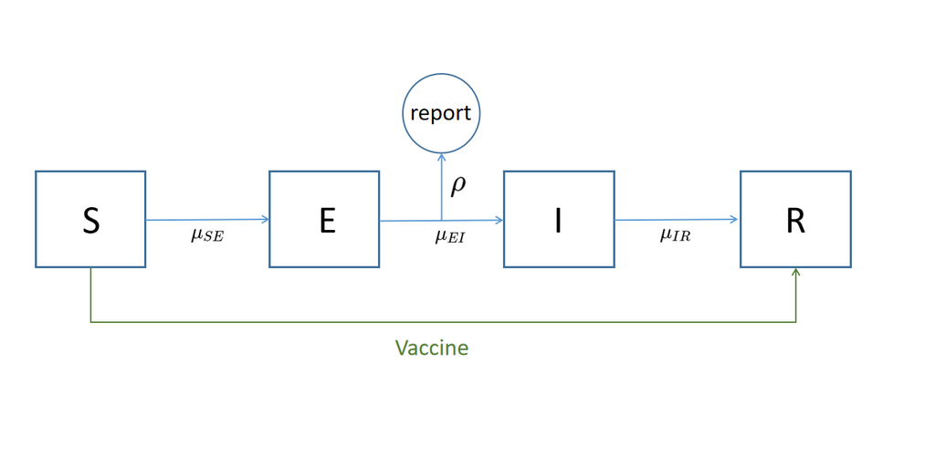

### 4.2.1 Model 1: SEIR with Constant Vaccine Number

In this part, we first regard our vaccine speed to be a constant number $V$. In each step of the SEIR process, we have the following relationship:
$$\begin{align*}
& N_{SE} = binomial(S,1-exp(-Beta*I/N*dt)) \\
& N_{EI} = binomial(E,1-exp(-\mu_{EI}*dt)) \\
& N_{IR} = binomial(I,1-exp(-\mu_{IR}*dt)) \\
& S = S - (N_{SE} + V) \\
& E = E + N_{SE} - N_{EI} \\
& I = I + N_{EI} - N_{IR} \\
& R = R + N_{IR} + V \\
& H = H + N_{IR}
\end{align*}$$

Additionally, we formulate our report number to be:
$$\begin{align*}
reports = binomial(H,\rho) \\
\end{align*}$$

#### Model 1 Implementation & Parameter Selection

```r
library(pomp)

seir_step <- Csnippet("
  double dN_SE = rbinom(S,1-exp(-Beta*I/N*dt));
  double dN_EI = rbinom(E,1-exp(-mu_EI*dt));
  double dN_IR = rbinom(I,1-exp(-mu_IR*dt));
  S -= (dN_SE + 2500);
  E += dN_SE - dN_EI;
  I += dN_EI - dN_IR;
  R += dN_IR + 2500;
  H += dN_IR;
")

seir_init <- Csnippet("
  S = nearbyint(eta*N);
  E = 110000;
  I = 17000;
  R = nearbyint((1-eta)*N);
  H = 0;
")

dmeas <- Csnippet("
  lik = dbinom(reports,H,rho,give_log);
  ")

rmeas <- Csnippet("
  reports = rbinom(H,rho);
  ")

dat %>%
  pomp(
    times="day",t0=0,
    rprocess=euler(seir_step,delta.t=1/8),
    rinit=seir_init,
    rmeasure=rmeas,
    dmeasure=dmeas,
    accumvars="H",
    partrans=parameter_trans(
      log=c("Beta","mu_EI"),
      logit=c("rho","eta")
    ),
    paramnames=c("N","Beta","mu_EI","mu_IR","rho","eta"),
    statenames=c("S","E","I","R","H")
  ) -> measSEIR
```

#### Result of Model 1: Constant Vaccine

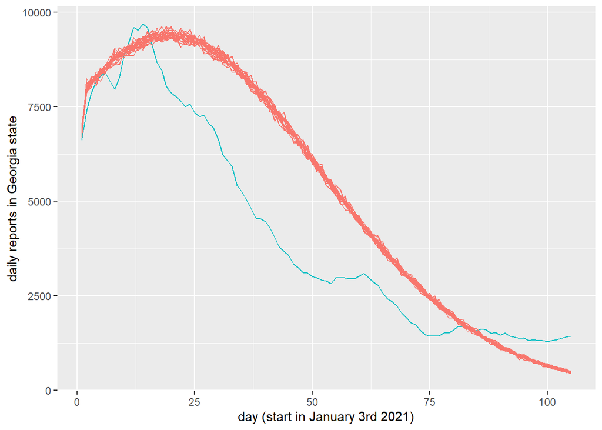

```r
set.seed(10000)
measSEIR %>%
  simulate(params=c(Beta=0.32,mu_EI=13,mu_IR=0.09,rho=0.7,eta=0.34,N=10610000),
    nsim=20,format="data.frame",include.data=TRUE) %>%
  ggplot(aes(x=day,y=reports,group=.id,color=.id=="data"))+
  geom_line()+ylab("daily reports in Georgia state") + xlab("day (start in January 3rd 2021)")+
  guides(color=FALSE)
```

### 4.2.2 Model 2: SEIR with Constant Vaccine Number + An Increasing Term

In this part, we regard our vaccine speed to be a constant number $V$ plus a linear increasing term according to the increasing trend in the real vaccine data by making use of the iteration term $index$. In each step of the SEIR process, we have the following relationship:

$$\begin{align*}
& N_{SE} = binomial(S,1-exp(-Beta*I/N*dt)) \\
& N_{EI} = binomial(E,1-exp(-\mu_{EI}*dt)) \\
& N_{IR} = binomial(I,1-exp(-\mu_{IR}*dt)) \\
& S = S - (N_{SE} + V + index*c) \\
& E = E + N_{SE} - N_{EI} \\
& I = I + N_{EI} - N_{IR} \\
& R = R + N_{IR} + V + index*c \\
& H = H + N_{IR}
\end{align*}$$

Additionally, we formulate our report number to be:
$$\begin{align*}
reports = binomial(H,\rho) \\
\end{align*}$$

#### Model 2 Implementation & Parameter Selection

```r
library(pomp)

seir_step <- Csnippet("
  double dN_SE = rbinom(S,1-exp(-Beta*I/N*dt));
  double dN_EI = rbinom(E,1-exp(-mu_EI*dt));
  double dN_IR = rbinom(I,1-exp(-mu_IR*dt));
  index += 1;
  S -= (dN_SE + 2200 + index*4);
  E += dN_SE - dN_EI;
  I += dN_EI - dN_IR;
  R += dN_IR + 2200 + index*4;
  H += dN_IR;
")

seir_init <- Csnippet("
  S = nearbyint(eta*N);
  E = 115000;
  I = 13500;
  R = nearbyint((1-eta)*N);
  H = 0;
  index = 1;
")

dmeas <- Csnippet("
  lik = dbinom(reports,H,rho,give_log);
  ")

rmeas <- Csnippet("
  reports = rbinom(H,rho);
  ")

dat %>%
  pomp(
    times="day",t0=0,
    rprocess=euler(seir_step,delta.t=1/8),
    rinit=seir_init,
    rmeasure=rmeas,
    dmeasure=dmeas,
    accumvars="H",
    partrans=parameter_trans(
      log=c("Beta","mu_EI"),
      logit=c("rho","eta")
    ),
    paramnames=c("N","Beta","mu_EI","mu_IR","rho","eta"),
    statenames=c("S","E","I","R","H","index")
  ) -> measSEIR
```

#### Results of Model 2: Constant Vaccine + Increasing Term

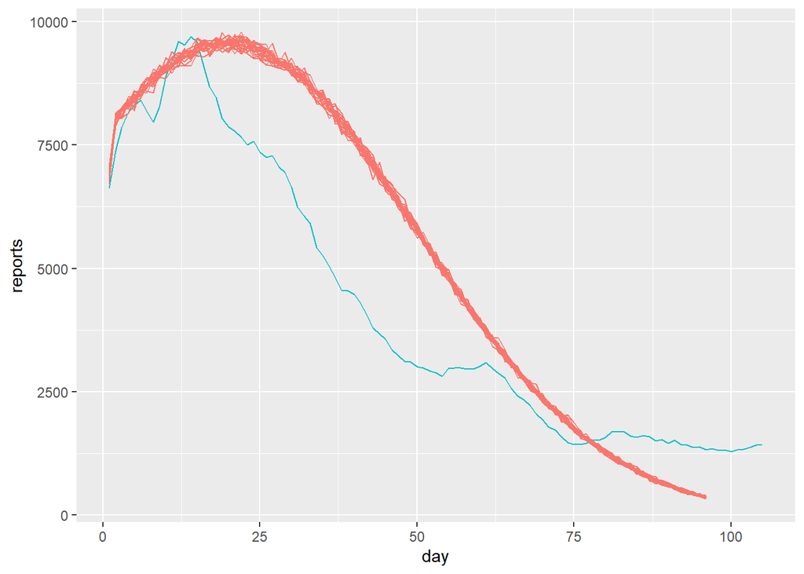

```r
set.seed(10000)
measSEIR %>%
  simulate(params=c(Beta=0.33,mu_EI=15,mu_IR=0.089,rho=0.7,eta=0.33,N=10610000),
    nsim=20,format="data.frame",include.data=TRUE) %>%
  ggplot(aes(x=day,y=reports,group=.id,color=.id=="data"))+
  geom_line()+
  guides(color=FALSE)
```

### 4.2.3 Model 3: SEIR with Vaccine Formulated as a Vaccination Rate

Different from the two previous approaches of regarding vaccination as a constant number, here we use a rate $\mu_{SV}$ in modeling the vaccination process. In each step of the SEIR process, we have the following relationship:

#### Model 3 Implementation & Parameter Selection

```r
library(pomp)

seir_step <- Csnippet("
  double dN_SE = rbinom(S,1-exp(-Beta*I/N*dt));
  double dN_EI = rbinom(E,1-exp(-mu_EI*dt));
  double dN_IR = rbinom(I,1-exp(-mu_IR*dt));
  double dN_SV = rbinom(S,1-exp(-mu_SV*dt));
  S -= (dN_SE + dN_SV);
  E += dN_SE - dN_EI;
  I += dN_EI - dN_IR;
  R += dN_IR + dN_SV;
  H += dN_IR;
")

seir_init <- Csnippet("
  S = nearbyint(eta*N);
  E = 115000;
  I = 13500;
  R = nearbyint((1-eta)*N);
  H = 0;
")

dmeas <- Csnippet("
  lik = dbinom(reports,H,rho,give_log);
  ")

rmeas <- Csnippet("
  reports = rbinom(H,rho);
  ")

dat %>%
  pomp(
    times="day",t0=0,
    rprocess=euler(seir_step,delta.t=1/8),
    rinit=seir_init,
    rmeasure=rmeas,
    dmeasure=dmeas,
    accumvars="H",
    partrans=parameter_trans(
      log=c("Beta","mu_EI"),
      logit=c("rho","eta")
    ),
    paramnames=c("N","Beta","mu_SV","mu_EI","mu_IR","rho","eta"),
    statenames=c("S","E","I","R","H")
  ) -> measSEIR
```

#### Results of Model 3: Using Vaccination Rate

This curve looks more natural in the curvature of modeling the trend. The “early stop” phenomenon in the curve among the last few points also disappeared.

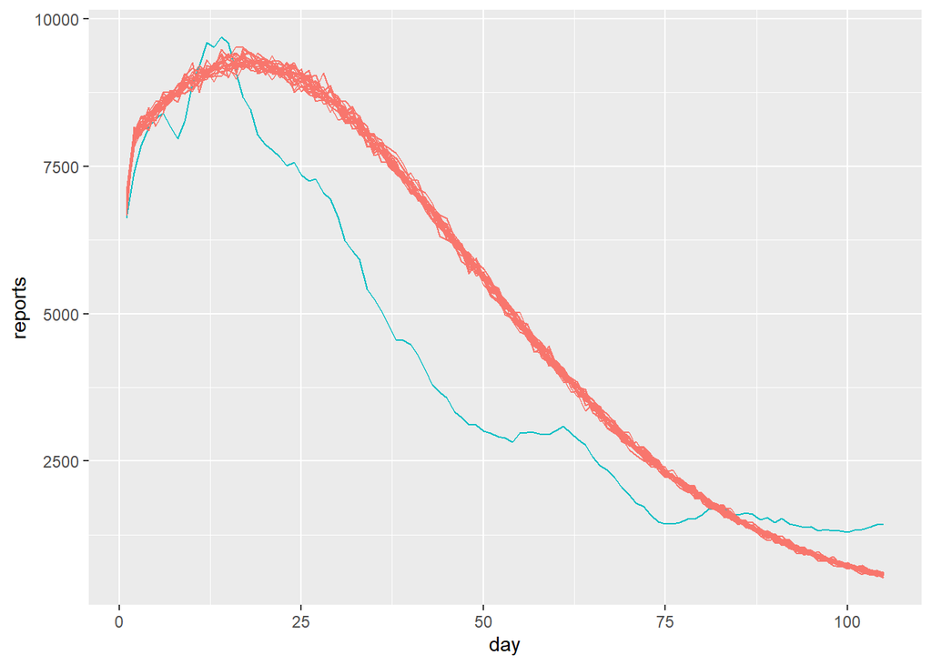

```r
set.seed(10000)
measSEIR %>%
  simulate(params=c(Beta=0.33,mu_SV=0.008,mu_EI=15,mu_IR=0.089,rho=0.7,eta=0.33,N=10620000),
    nsim=20,format="data.frame",include.data=TRUE) %>%
  ggplot(aes(x=day,y=reports,group=.id,color=.id=="data"))+
  geom_line()+
  guides(color=FALSE)
```

## 5. Conclusion and Future Work

The possible reason for the imperfect simulation maybe due to the constant contact rate we use. In our future study, we may need to divide our study period into different sub-period and use different contact rate.

Another reason for the imperfect simulation might be the lack of successful local & global search. If we can overcome the unsolved obstacles in the future analysis, local & global search may lead to better estimations of the parameters. Our current attempts on local & global search can be find in the Appendix part.

## 6. Reference

[1] https://en.wikipedia.org/wiki/COVID-19_vaccine#/media/File:Vaccine_candidate_mechanisms_for_SARS-CoV-2_(49948301838).jpg  
[2] Data Source 1 (covid data): https://raw.githubusercontent.com/nytimes/covid-19-data/master/us-states.csv  
[3] Data Source 2 (vaccine data):https://raw.githubusercontent.com/owid/covid-19-data/master/public/data/vaccinations/us_state_vaccinations.csv  
[4] https://ionides.github.io/531w21/  
[5] https://www.ncbi.nlm.nih.gov/pmc/articles/PMC7186134/  
[6] https://clinmedjournals.org/articles/jide/journal-of-infectious-diseases-and-epidemiology-jide-6-144.php?jid=jide  
[7] https://en.wikipedia.org/wiki/Demographics_of_Georgia_(U.S._state)

## 7. Specification of Individual Role

Description of individual contributions removed for anonymity

## 8. Appendix

#### Result of attempt for the naive local search

We also tried to conduct the local search, however, we found that most of the conditional logliklihood is -inf, which maybe due to the binomial distribution and the higher reporting rate we use according to the notes.

```r
library(pomp)
seir_step <- Csnippet("
  double dN_SE = rbinom(S,1-exp(-Beta*I/N*dt));
  double dN_EI = rbinom(E,1-exp(-mu_EI*dt));
  double dN_IR = rbinom(I,1-exp(-mu_IR*dt));
  S -= (dN_SE + 2500);
  E += dN_SE - dN_EI;
  I += dN_EI - dN_IR;
  R += dN_IR + 2500;
  H += dN_IR;
")

seir_init <- Csnippet("
  S = nearbyint(eta*N);
  E = 110000;
  I = 17000;
  R = nearbyint((1-eta)*N);
  H = 0;
")

dmeas <- Csnippet("
  lik = dbinom(reports,H,rho,give_log);
  ")

rmeas <- Csnippet("
  reports = rbinom(H,rho);
  ")

dat %>%
  pomp(
    times="day",t0=0,
    rprocess=euler(seir_step,delta.t=1/8),
    rinit=seir_init,
    rmeasure=rmeas,
    dmeasure=dmeas,
    accumvars="H",
    partrans=parameter_trans(
      log=c("Beta","mu_EI"),
      logit=c("rho","eta")
    ),
    paramnames=c("N","Beta","mu_EI","mu_IR","rho","eta"),
    statenames=c("S","E","I","R","H")
  ) -> measSEIR

library(tidyverse)
params=c(Beta=0.32,mu_EI=13,mu_IR=0.09,rho=0.7,eta=0.34,N=10610000)
measSEIR %>%
  simulate(params=params,nsim=10,format="data.frame") -> y
measSEIR %>%
  pfilter(Np=1000,params=params) -> pf
fixed_params <- c(N=10610000)
plot(pf)
```

[output not shown]

#### Result of local search using negative binomial distribution and lower reporting rate

However, after using the negative binomial distribution and lower reporting rate(decrease from 0.7 to 0.2), we still get the -inf logliklihood.

```r
library(pomp)

seir_step <- Csnippet("
  double dN_SE = rbinom(S,1-exp(-Beta*I/N*dt));
  double dN_EI = rbinom(E,1-exp(-mu_EI*dt));
  double dN_IR = rbinom(I,1-exp(-mu_IR*dt));
  S -= (dN_SE + 1000);
  E += dN_SE - dN_EI;
  I += dN_EI - dN_IR;
  R += dN_IR + 1000;
  H += dN_IR;
")

seir_init <- Csnippet("
  S = nearbyint(eta*N);
  E = 100000;
  I = 17000;
  R = nearbyint((1-eta)*N);
  H = 0;
")

dmeas <- Csnippet("
  lik = dnbinom(reports,H,rho,give_log);
  ")

rmeas <- Csnippet("
  reports = rnbinom(H,rho);
  ")

dat %>%
  pomp(
    times="day",t0=0,
    rprocess=euler(seir_step,delta.t=1/8),
    rinit=seir_init,
    rmeasure=rmeas,
    dmeasure=dmeas,
    accumvars="H",
    partrans=parameter_trans(
      log=c("Beta","mu_EI"),
      logit=c("rho","eta")
    ),
    paramnames=c("N","Beta","mu_EI","mu_IR","rho","eta"),
    statenames=c("S","E","I","R","H")
  ) -> measSEIR

library(tidyverse)
params=c(Beta=0.31,mu_EI=15,mu_IR=0.088,rho=0.2,eta=0.35,N=10610000)
measSEIR %>%
  simulate(params=params,nsim=10,format="data.frame") -> y
measSEIR %>%
  pfilter(Np=1000,params=params) -> pf
fixed_params <- c(N=10610000)
plot(pf)
```

[output not shown]